# digit_classification_from_scratch

```python
import jax.numpy as jnp
from jax import grad, jit, vmap
from jax import random
```

```python
# A helper function to randomly initialize weights and biases
# for a dense neural network layer
def random_layer_params(m, n, key, scale=1e-2):
  w_key, b_key = random.split(key)
  return scale * random.normal(w_key, (n, m)), scale * random.normal(b_key, (n,))

# Initialize all layers for a fully-connected neural network with sizes "sizes"
def init_network_params(sizes, key):
  keys = random.split(key, len(sizes))
  return [random_layer_params(m, n, k) for m, n, k in zip(sizes[:-1], sizes[1:], keys)]

layer_sizes = [784, 512, 512, 10]
step_size = 0.01
num_epochs = 10
batch_size = 128
n_targets = 10
params = init_network_params(layer_sizes, random.PRNGKey(0))
```

```python
from jax.scipy.special import logsumexp

def relu(x):
    return jnp.maximum(0, x)

def predict(params, image):
  # per-example predictions
  activations = image
  for w, b in params[:-1]:
    outputs = jnp.dot(w, activations) + b
    activations = relu(outputs)

  final_w, final_b = params[-1]
  logits = jnp.dot(final_w, activations) + final_b
  return logits - logsumexp(logits)
```

```python
# This works on single examples
random_flattened_image = random.normal(random.PRNGKey(1), (28 * 28,))
preds = predict(params, random_flattened_image)
print(preds.shape)
```

```
(10,)
```

```python
# Doesn't work with a batch
random_flattened_images = random.normal(random.PRNGKey(1), (10, 28 * 28))
try:
  preds = predict(params, random_flattened_images)
except TypeError:
  print('Invalid shapes!')
```

```
Invalid shapes!
```

```python
# Let's upgrade it to handle batches using `vmap`

# Make a batched version of the `predict` function
batched_predict = vmap(predict, in_axes=(None, 0))

# `batched_predict` has the same call signature as `predict`
batched_preds = batched_predict(params, random_flattened_images)
print(batched_preds.shape)
```

```
(10, 10)
```

```python
def one_hot(x, k, dtype=jnp.float32):
  """Create a one-hot encoding of x of size k."""
  return jnp.array(x[:, None] == jnp.arange(k), dtype)

def accuracy(params, images, targets):
  target_class = jnp.argmax(targets, axis=1)
  predicted_class = jnp.argmax(batched_predict(params, images), axis=1)
  return jnp.mean(predicted_class == target_class)

def loss(params, images, targets):
  preds = batched_predict(params, images)
  return -jnp.mean(preds * targets)

@jit
def update(params, x, y):
  grads = grad(loss)(params, x, y)
  return [(w - step_size * dw, b - step_size * db)
          for (w, b), (dw, db) in zip(params, grads)]
```

```python
# import os
# import gzip
# import numpy as np
# import urllib.request

# # URLs for the MNIST dataset
# URLS = {
#     'train_images': 'http://yann.lecun.com/exdb/mnist/train-images-idx3-ubyte.gz',
#     'train_labels': 'http://yann.lecun.com/exdb/mnist/train-labels-idx1-ubyte.gz',
#     'test_images': 'http://yann.lecun.com/exdb/mnist/t10k-images-idx3-ubyte.gz',
#     'test_labels': 'http://yann.lecun.com/exdb/mnist/t10k-labels-idx1-ubyte.gz',
# }

# def download_and_extract_mnist(url, dest):
#     """Download and extract MNIST files."""
#     if not os.path.exists(dest):
#         urllib.request.urlretrieve(url, dest)
#     with gzip.open(dest, 'rb') as f:
#         return np.frombuffer(f.read(), np.uint8, offset=16).reshape(-1, 784)

# def download_and_extract_labels(url, dest):
#     """Download and extract MNIST label files."""
#     if not os.path.exists(dest):
#         urllib.request.urlretrieve(url, dest)
#     with gzip.open(dest, 'rb') as f:
#         return np.frombuffer(f.read(), np.uint8, offset=8)

# # Download and preprocess data
# train_images = download_and_extract_mnist(URLS['train_images'], '/tmp/train-images-idx3-ubyte.gz')
# train_labels = download_and_extract_labels(URLS['train_labels'], '/tmp/train-labels-idx1-ubyte.gz')
# test_images = download_and_extract_mnist(URLS['test_images'], '/tmp/t10k-images-idx3-ubyte.gz')
# test_labels = download_and_extract_labels(URLS['test_labels'], '/tmp/t10k-labels-idx1-ubyte.gz')

import os
import gzip
import shutil
import numpy as np
import urllib.request
from urllib.error import URLError
from zipfile import ZipFile
from io import BytesIO

# URL for the MNIST dataset ZIP file
MNIST_ZIP_URL = 'https://data.deepai.org/mnist.zip'

def download_and_extract_mnist_zip(url, dest_folder):
    """Download and extract the MNIST ZIP file."""
    if not os.path.exists(dest_folder):
        os.makedirs(dest_folder)
    zip_path = os.path.join(dest_folder, 'mnist.zip')
    try:
        urllib.request.urlretrieve(url, zip_path)
    except URLError as e:
        print(f"Failed to download the dataset. Error: {e}")
        return False
    with ZipFile(zip_path, 'r') as zip_ref:
        zip_ref.extractall(dest_folder)
    os.remove(zip_path)
    return True

def extract_gz_file(gz_path, dest_path):
    """Extract a .gz file."""
    with gzip.open(gz_path, 'rb') as f_in:
        with open(dest_path, 'wb') as f_out:
            shutil.copyfileobj(f_in, f_out)

def load_mnist_images(file_path):
    """Load MNIST images from the IDX file format."""
    with open(file_path, 'rb') as f:
        data = np.frombuffer(f.read(), np.uint8, offset=16)
    return data.reshape(-1, 784)

def load_mnist_labels(file_path):
    """Load MNIST labels from the IDX file format."""
    with open(file_path, 'rb') as f:
        data = np.frombuffer(f.read(), np.uint8, offset=8)
    return data

# Define paths
data_folder = '/tmp/mnist_data'
train_images_path = os.path.join(data_folder, 'train-images-idx3-ubyte')
train_labels_path = os.path.join(data_folder, 'train-labels-idx1-ubyte')
test_images_path = os.path.join(data_folder, 't10k-images-idx3-ubyte')
test_labels_path = os.path.join(data_folder, 't10k-labels-idx1-ubyte')

# Download and extract the MNIST dataset
if download_and_extract_mnist_zip(MNIST_ZIP_URL, data_folder):
    # Extract .gz files
    extract_gz_file(train_images_path + '.gz', train_images_path)
    extract_gz_file(train_labels_path + '.gz', train_labels_path)
    extract_gz_file(test_images_path + '.gz', test_images_path)
    extract_gz_file(test_labels_path + '.gz', test_labels_path)

    # Load data
    train_images = load_mnist_images(train_images_path)
    train_labels = load_mnist_labels(train_labels_path)
    test_images = load_mnist_images(test_images_path)
    test_labels = load_mnist_labels(test_labels_path)

    # One-hot encoding of labels
    def one_hot(labels, num_classes):
        return np.eye(num_classes)[labels]

    num_labels = 10  # MNIST has 10 classes
    train_labels = one_hot(train_labels, num_labels)
    test_labels = one_hot(test_labels, num_labels)

    print("MNIST dataset successfully downloaded and processed.")
else:
    print("Failed to download and process the MNIST dataset.")
```

```
MNIST dataset successfully downloaded and processed.
```

```python
print('Train:', train_images.shape, train_labels.shape)
print('Test:', test_images.shape, test_labels.shape)
```

```
Train: (60000, 784) (60000, 10)
Test: (10000, 784) (10000, 10)
```

```python
import time
import numpy as np

def get_train_batches(batch_size):
    """Yield batches of train data."""
    num_samples = train_images.shape[0]
    indices = np.arange(num_samples)
    np.random.shuffle(indices)  # shuffle the indices for randomness

    for start_idx in range(0, num_samples, batch_size):
        end_idx = min(start_idx + batch_size, num_samples)
        batch_indices = indices[start_idx:end_idx]
        yield train_images[batch_indices], train_labels[batch_indices]

# Assuming you have defined num_epochs, batch_size, and update functions
for epoch in range(num_epochs):
    start_time = time.time()
    for x, y in get_train_batches(batch_size):
        x = x.reshape(len(x), -1)  # Flatten the images if not already
        params = update(params, x, y)
    epoch_time = time.time() - start_time

    train_acc = accuracy(params, train_images.reshape(len(train_images), -1), train_labels)
    test_acc = accuracy(params, test_images.reshape(len(test_images), -1), test_labels)
    print("Epoch {} in {:0.2f} sec".format(epoch, epoch_time))
    print("Training set accuracy {}".format(train_acc))
    print("Test set accuracy {}".format(test_acc))
```

```
Epoch 0 in 1.23 sec
Training set accuracy 0.9211333394050598
Test set accuracy 0.925599992275238
Epoch 1 in 0.98 sec
Training set accuracy 0.9387000203132629
Test set accuracy 0.9387999773025513
Epoch 2 in 0.95 sec
Training set accuracy 0.9493666887283325
Test set accuracy 0.9474999904632568
Epoch 3 in 0.97 sec
Training set accuracy 0.9588666558265686
Test set accuracy 0.9545999765396118
Epoch 4 in 1.01 sec
Training set accuracy 0.9646666646003723
Test set accuracy 0.9580000042915344
Epoch 5 in 0.98 sec
Training set accuracy 0.9681833386421204
Test set accuracy 0.9613999724388123
Epoch 6 in 1.00 sec
Training set accuracy 0.9719833731651306
Test set accuracy 0.9643999934196472
Epoch 7 in 1.00 sec
Training set accuracy 0.9759166836738586
Test set accuracy 0.9661999940872192
Epoch 8 in 0.99 sec
Training set accuracy 0.9773333668708801
Test set accuracy 0.9686999917030334
Epoch 9 in 1.00 sec
Training set accuracy 0.9798166751861572
Test set accuracy 0.9699999690055847
```

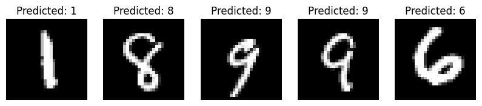

```python
import matplotlib.pyplot as plt
import numpy as np

# Placeholder for the model's predict function
# Replace this with your actual model's prediction method

# Select five random test images
num_samples = 5
indices = np.random.choice(len(test_images), num_samples, replace=False)
selected_images = test_images[indices]
selected_labels = test_labels[indices]

# Generate predictions
# Replace 'model' with your actual model
predicted_labels = np.argmax(batched_predict(params, selected_images),axis=1)

# Visualize the images and the predictions
plt.figure(figsize=(10, 2))
for i, (image, label) in enumerate(zip(selected_images, predicted_labels)):
    plt.subplot(1, num_samples, i + 1)
    plt.imshow(image.reshape(28, 28), cmap='gray')
    plt.title(f'Predicted: {label}')
    plt.axis('off')
plt.show()
```

## Next draw your own digits!

```python
import tkinter as tk
from tkinter import Canvas
import numpy as np
from PIL import Image, ImageDraw


# Function to draw on the canvas
def draw(event):
    x, y = event.x, event.y
    canvas.create_oval((x, y, x + 10, y + 10), fill='black')
    draw_image.line([x, y, x + 1, y + 1], fill='black', width=10)

# Function to predict the digit
def predict_digit():
    canvas.postscript(file='digit.eps', colormode='color')
    img = Image.open('digit.eps')
    if img.mode != 'L':
        img = img.convert('L')
    img = img.resize((28, 28), Image.Resampling.LANCZOS)
    img = np.array(img)
    img = 1-img / 255.0

    digit = np.argmax(predict(params,np.ndarray.flatten(img)))
    label.config(text=str(digit))


# Function to clear the canvas and the image
def clear_canvas():
    canvas.delete("all")
    draw_image.rectangle((0, 0, 150, 150), fill='white')
    label.config(text="Draw a digit")

# Create the main window
root = tk.Tk()
root.title("Digit Predictor")

# Create a drawing canvas
canvas = Canvas(root, width=150, height=150, bg='white')
canvas.pack()

# PIL Image and Draw for capturing the drawn digit
image = Image.new("RGB", (150, 150), 'white')
draw_image = ImageDraw.Draw(image)

# Bind the drawing function to mouse drag
canvas.bind("<B1-Motion>", draw)

# Add a button to predict the digit
button_predict = tk.Button(root, text="Predict", command=predict_digit)
button_predict.pack()

# Add a button to clear the canvas
button_clear = tk.Button(root, text="Clear", command=clear_canvas)
button_clear.pack()

# Label to display the prediction
label = tk.Label(root, text="Draw a digit", font=("Helvetica", 16))
label.pack()

# Run the application
root.mainloop()
```

# Discussion

1. (1 point) How many layers are there in the neural network?  
   There are 3 layers in the neural network: `[784, 512, 512, 10]`. `784` is the input dimension and hence isn't counted.
2. (1 point) What are the shapes of each parameter in "params"?  
   Layer 1: `W1`: `(512, 784)`, `b1`: `(512,)`  
   Layer 2: `W2`: `(512, 512)`, `b2`: `(512,)`  
   Layer 3: `W3`: `(10, 512)`, `b3`: `(10,)`
3. (2 points) Which activation function is used?  
   ReLU as defined in the `relu` function.
4. (2 points) What are the input space and label space?  
   The input space is a flattened MNISTS image of 28x28 pixels, hence 784. In a batch it woudl be `(batch_size, 784)`. The output space is a one-hot vector of length 10 (each representing a digit 0-9).
5. (2 points) What does ``predict'' output?  
   Returns a log-softmax output vector of length 10 each representing a digit 0-9, normalized so the probabilities sum to 1. The highest probability index indicates the predicted digit.
6. (2 points) What are the training accuracy and test accuracy after 10 epochs? Use the GUI, write your 1,2,3,4,...,10 using your mouse. Write a short report that shows your digits and the classification results.  
   The training accuracy after 10 epochs is 0.98, the test accuracy is 0.97.

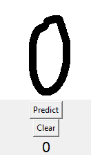

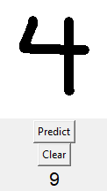

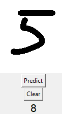

   The model cleary struggles to correctly identify my handwritten digits. Do note that I changed some code for the PIL Resampling to `LANCZOS` instead of `ANTIALIAS` as it is deprecated in my Pillow version. Online research says the algorithm is the same so it technically shouldn't affect results. It seems the model struggles to identify between the curves of each number and thus can't correctly associate each digit with its correct digit.
7. (2 points) What is the classification accuracy on your data? Is it better or worse than the accuracy on the test set? If it is very different, could you explain why? Any ideas to fix the issue?  
   The classification accuracy is 30%. This is signifcantly worse than the accuracy on the test set. One would assume that with a test set accuracy of 97% the model would be able to identify my handwritten digits. We could fix this issue by providing more training data of varied digits. The best way to fix this would be to provide sets of training data of my own handwritten digits, and then train the model on this.